# Graphs in Python: Boxplots with Significance Bars *using explicitly defined axes in Matplotlib*

⇦ Back

**Boxplots** - also known as **box-and-whisker** plots - are often used with groups of numerical data. They are useful for quickly comparing differences in *spread*, *skewness* and *central tendency*. If a statistical hypothesis test is used to infer a *statistical difference* between the groups (eg a *t*-test to detect a difference in means or the Mann–Whitney *U* test to detect a difference in expected value) it is usual to represent this finding on the plot via **significance bars**. This page will demonstrate how to create these dynamically, ie in such a way as to work for most use cases with minimal changes to the code.

# 1 Example Data

This first example will use the *Iris* flower data set - see [here](https://en.wikipedia.org/wiki/Iris_flower_data_set) and [here](https://scikit-learn.org/stable/modules/generated/sklearn.datasets.load_iris.html#sklearn.datasets.load_iris) - which can be loaded from the **scikit-learn** library via the `load_iris()` function:

```python
from sklearn.datasets import load_iris

# Load the dataset
iris = load_iris()
```

Let’s re-configure the data into a more Pandas-friendly format to make it easier to work with:

```python
import pandas as pd

# Extract the data
data = pd.DataFrame(iris['data'], columns=iris['feature_names'])
# Extract the target
target = pd.DataFrame(iris['target'], columns=['species'])
# Translate the target
class2species = dict(enumerate(iris['target_names']))
target['species'] = target['species'].replace(class2species)
# Combine into one dataset
df = pd.concat([target, data], axis='columns')
```

Now let’s take a look at what we’re working with:

```python
# Pandas display options
pd.set_option('display.max_columns', None)
pd.set_option('display.max_rows', None)
pd.set_option('display.max_colwidth', 40)
pd.set_option('display.width', 362)

print(df.head())
```

```
##   species  sepal length (cm)  sepal width (cm)  petal length (cm)  petal width (cm)
## 0  setosa                5.1               3.5                1.4               0.2
## 1  setosa                4.9               3.0                1.4               0.2
## 2  setosa                4.7               3.2                1.3               0.2
## 3  setosa                4.6               3.1                1.5               0.2
## 4  setosa                5.0               3.6                1.4               0.2
```

Only one species is visible in this preview of the data - “setosa”. There are two others in the full data set: “versicolor” and “virginica”.

# 2 Initialise the Plot

Let’s create a boxplot to which we can add significance bars. Specifically, let’s graph the *petal length* values and let’s use the `boxplot()` function from Matplotlib. This function takes a *list* as its input, and each element of this list is then used as the data for each group (box) in the boxplot. So let’s split our data frame up into a *list-of-series* (one series for each of the three species of Iris flower) of petal length values which will then be ready for plotting:

```python
# Convert to a list of series
col = 'petal length (cm)'
data = [
    df[df['species'] == 'setosa'][col],
    df[df['species'] == 'versicolor'][col],
    df[df['species'] == 'virginica'][col],
]
```

## 2.1 Basic Plot

As promised, here’s the `boxplot()` function:

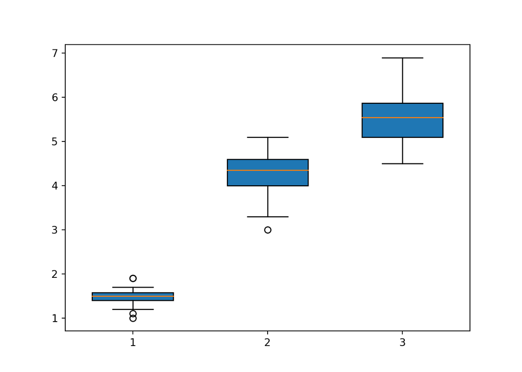

```python
import matplotlib.pyplot as plt

# Create a set of axes
ax = plt.axes()
# Create a boxplot on the axes
bp = ax.boxplot(data, widths=0.6, patch_artist=True)

plt.show()
```

The `widths` parameter sets the width of the boxes as a proportion of the available space (ie `widths=1` will leave no space between boxes). Turning the `patch_artist` parameter on adds colours to the boxes.

## 2.2 Format the Plot

Let’s start with setting some general Matpotlib parameters:

```python
# Make figures A6 in size
A = 6
plt.rc('figure', figsize=[46.82 * .5**(.5 * A), 33.11 * .5**(.5 * A)])
# Change figure quality
plt.rc('figure', dpi=141)
# Use LaTeX for graphs' text
plt.rc('text', usetex=True)
# Use the serif font
plt.rc('font', family='serif')
# Be able to use Greek symbols in text mode
plt.rc('text.latex', preamble=r'\usepackage{textgreek}')
```

Now let’s add in some detail around the plot itself:

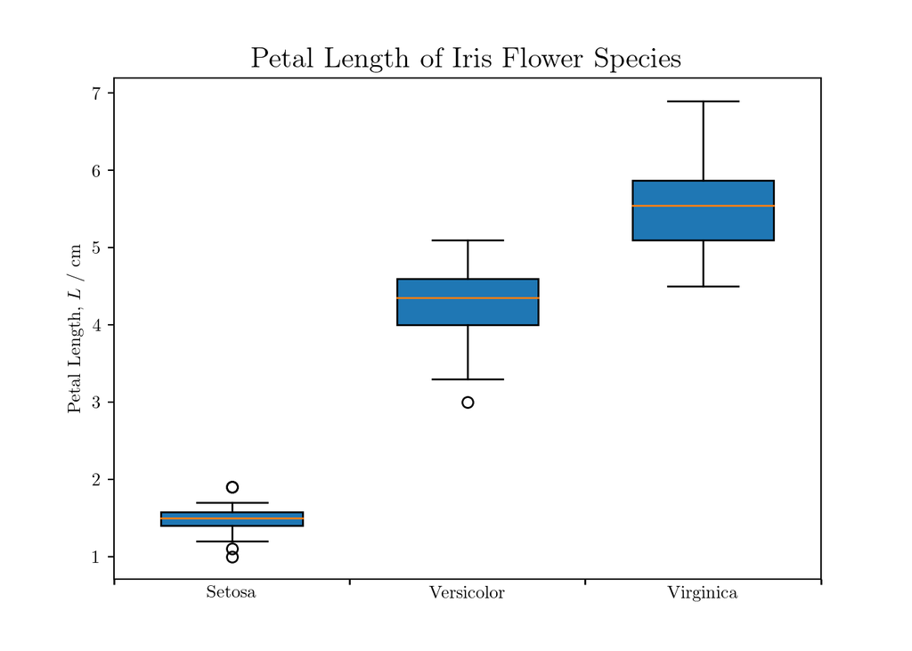

```python
# Create a set of axes
ax = plt.axes()
# Create a boxplot on the axes
bp = ax.boxplot(data, widths=0.6, patch_artist=True)
# Graph title
ax.set_title('Petal Length of Iris Flower Species', fontsize=16)
# Label y-axis
ax.set_ylabel(r'Petal Length, $L$ / cm')
# Label x-axis ticks
xticklabels = iris['target_names']
xticklabels = [label.title() for label in xticklabels]
ax.set_xticklabels(xticklabels)
# Hide x-axis major ticks
ax.tick_params(axis='x', which='major', length=0)
# Show x-axis minor ticks
xticks = [0.5] + [x + 0.5 for x in ax.get_xticks()]
ax.set_xticks(xticks, minor=True)
# Clean up the appearance
ax.tick_params(axis='x', which='minor', length=3, width=1)

plt.show()
```

## 2.3 Add Colour

Opinions differ as to how boxplots should be coloured, if at all, so it’s probably best to consult a style guide that’s relevant to you. For the record, here’s how to use Seaborn’s pastel colour palette to brighten up the boxes (and also how to re-colour the median lines):

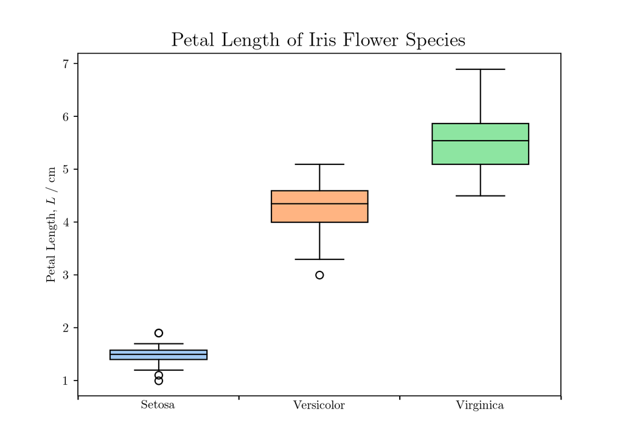

```python
import seaborn as sns

# Create a set of axes
ax = plt.axes()
# Create a boxplot on the axes
bp = ax.boxplot(data, widths=0.6, patch_artist=True)
# Graph title
ax.set_title('Petal Length of Iris Flower Species', fontsize=16)
# Label y-axis
ax.set_ylabel(r'Petal Length, $L$ / cm')
# Label x-axis ticks
xticklabels = iris['target_names']
xticklabels = [label.title() for label in xticklabels]
ax.set_xticklabels(xticklabels)
# Hide x-axis major ticks
ax.tick_params(axis='x', which='major', length=0)
# Show x-axis minor ticks
xticks = [0.5] + [x + 0.5 for x in ax.get_xticks()]
ax.set_xticks(xticks, minor=True)
# Clean up the appearance
ax.tick_params(axis='x', which='minor', length=3, width=1)

# Change the colour of the boxes to Seaborn's 'pastel' palette
colors = sns.color_palette('pastel')
for patch, color in zip(bp['boxes'], colors):
    patch.set_facecolor(color)

# Colour of the median lines
plt.setp(bp['medians'], color='k')

plt.show()
```

# 3 Test for Statistical Significance

Cycle through each of the pairs of groups and use the Mann–Whitney *U* test to decide if there is a significant difference between them. One way to do this would be to use the `combinations()` function from the `itertools` module to generate all *combinations* of two species:

```python
import itertools

species = iris['target_names']
# Generate all the combinations of two groups
combinations = itertools.combinations(species, 2)
for combination in combinations:
    print(combination)
```

```
## ('setosa', 'versicolor')
## ('setosa', 'virginica')
## ('versicolor', 'virginica')
```

For each pair of species we could extract their data and perform the hypothesis testing. While this would work perfectly fine, it turns out that adding significance bars to boxplots is neater and more readable if it is done *outer pairs first*. The `combinations()` function does *pairs including the first group* first. The following code can be used to generate combinations in the preferred way:

```python
# Check from the outside pairs of boxes inwards
ls = list(range(1, len(data) + 1))
combinations = [(ls[x], ls[x + y]) for y in reversed(ls) for x in range((len(ls) - y))]
for combination in combinations:
    print(combination)
```

```
## (1, 3)
## (1, 2)
## (2, 3)
```

Here it is in action, generating the pairs of groups, extracting the data and testing for significant differences using the `mannwhitneyu()` function from Scipy:

```python
from scipy import stats

# Initialise a list of combinations of groups that are significantly different
significant_combinations = []
# Check from the outside pairs of boxes inwards
ls = list(range(1, len(data) + 1))
combinations = [(ls[x], ls[x + y]) for y in reversed(ls) for x in range((len(ls) - y))]
for combination in combinations:
    data1 = data[combination[0] - 1]
    data2 = data[combination[1] - 1]
    # Significance
    U, p = stats.mannwhitneyu(data1, data2, alternative='two-sided')
    if p < 0.05:
        significant_combinations.append([combination, p])

print(significant_combinations)
```

```
## [[(1, 3), 5.665214485738232e-18], [(1, 2), 5.651011584290147e-18], [(2, 3), 9.133544727668256e-17]]
```

All three combinations of groups are significantly different.

# 4 Add Significance Bars

To plot the bars, plot three straight line segments above each pair of boxes that are significantly different:

- A short upwards line
- A horizontal line
- A short downwards line

Then, convert the relevant $p$-value into a significance level (either one, two or three asterisks) and add that above the bar as text:

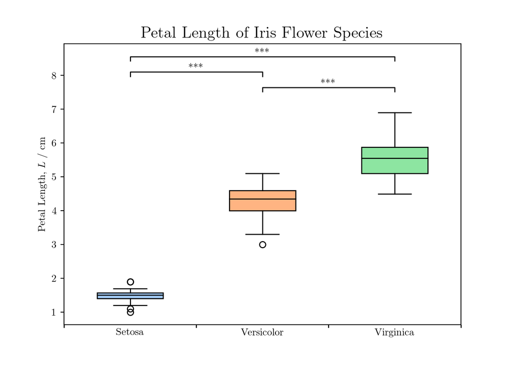

```python
# Create a set of axes
ax = plt.axes()
# Create a boxplot on the axes
bp = ax.boxplot(data, widths=0.5, patch_artist=True)
# Graph title
ax.set_title('Petal Length of Iris Flower Species', fontsize=16)
# Label y-axis
ax.set_ylabel(r'Petal Length, $L$ / cm')
# Label x-axis ticks
xticklabels = iris['target_names']
xticklabels = [label.title() for label in xticklabels]
ax.set_xticklabels(xticklabels)
# Hide x-axis major ticks
ax.tick_params(axis='x', which='major', length=0)
# Show x-axis minor ticks
xticks = [0.5] + [x + 0.5 for x in ax.get_xticks()]
ax.set_xticks(xticks, minor=True)
# Clean up the appearance
ax.tick_params(axis='x', which='minor', length=3, width=1)

# Change the colour of the boxes to Seaborn's 'pastel' palette
colors = sns.color_palette('pastel')
for patch, color in zip(bp['boxes'], colors):
    patch.set_facecolor(color)

# Colour of the median lines
plt.setp(bp['medians'], color='k')

# Get the y-axis limits
bottom, top = ax.get_ylim()
y_range = top - bottom

# Significance bars
for i, significant_combination in enumerate(significant_combinations):
    # Columns corresponding to the datasets of interest
    x1 = significant_combination[0][0]
    x2 = significant_combination[0][1]
    # What level is this bar among the bars above the plot?
    level = len(significant_combinations) - i
    # Plot the bar
    bar_height = (y_range * 0.07 * level) + top
    bar_tips = bar_height - (y_range * 0.02)
    plt.plot(
        [x1, x1, x2, x2],
        [bar_tips, bar_height, bar_height, bar_tips], lw=1, c='k'
    )
    # Significance level
    p = significant_combination[1]
    if p < 0.001:
        sig_symbol = '***'
    elif p < 0.01:
        sig_symbol = '**'
    elif p < 0.05:
        sig_symbol = '*'
    text_height = bar_height + (y_range * 0.01)
    plt.text((x1 + x2) * 0.5, text_height, sig_symbol, ha='center', va='bottom', c='k')

plt.show()
```

## 4.1 Annotate the Sample Sizes

A final touch that will improve how the graph looks will be to add the sample sizes as annotations below the boxes:

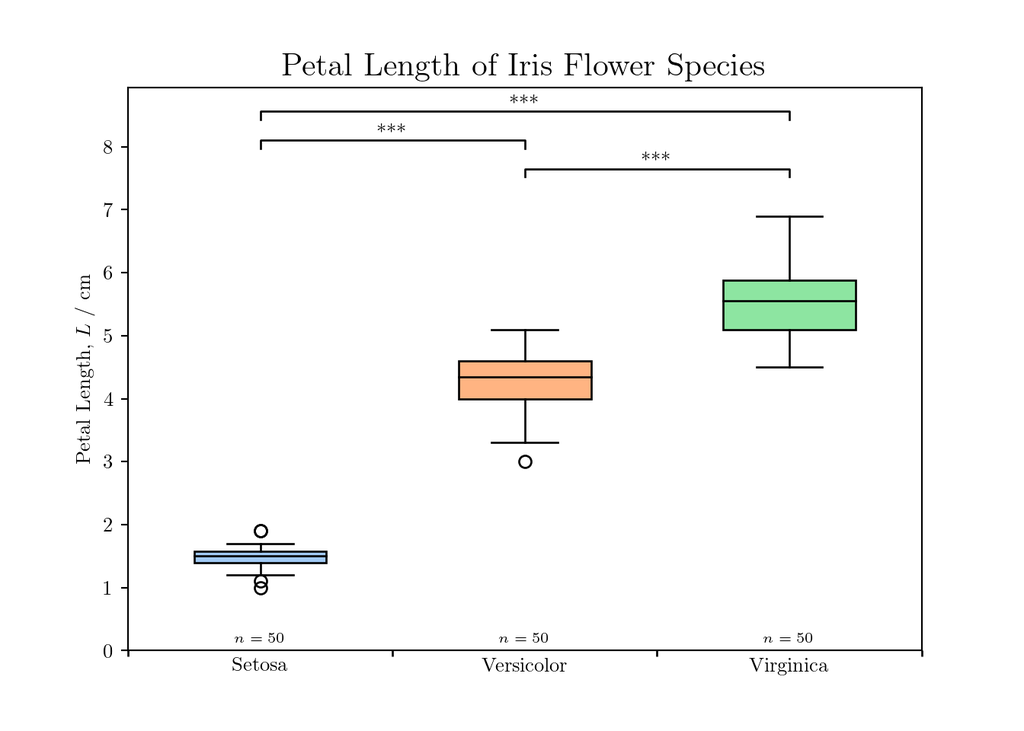

```python
# Adjust y-axis
ax.set_ylim(0, ax.get_ylim()[1])

# Annotate sample size below each box
for i, dataset in enumerate(data):
    sample_size = len(dataset)
    ax.text(i + 1, 0 + y_range * 0.02, fr'$n = {sample_size}$', ha='center', size='x-small')

plt.show()
```

# 5 Convert into a Function

The above code is fine for doing one plot at a time, but we could really do with a solution that will work again and again for as many plots as we need. Firstly, let’s generate some new example data that we can use to practice:

## 5.1 Example Data

We’ll use Numpy to generate lists (groups) of random data points from the normal distribution with increasing means and standard deviations, and with random sample sizes:

```python
import numpy as np

# Set the seed to ensure we always get the same random numbers each time we run the code
np.random.seed(20220922)

# Create a list-of-lists, where each sub-list contains random data from the normal distribution
data = []
for x in range(2):
    # Mean
    mu = 650 + 60 * x
    # Standard deviation
    sigma = 50 + 20 * x
    # Sample size
    n = 30 + np.random.randint(0, 60)
    # Create data points and add to master list
    data.append(np.random.normal(mu, sigma, n))
```

## 5.2 Create Function

Using the graph-plotting script from above we can create a graph-plotting function:

```python
def box_and_whisker(data, title, ylabel, xticklabels):
    """
    Create a box-and-whisker plot with significance bars.
    """
    ax = plt.axes()
    bp = ax.boxplot(data, widths=0.6, patch_artist=True)
    # Graph title
    ax.set_title(title, fontsize=14)
    # Label y-axis
    ax.set_ylabel(ylabel)
    # Label x-axis ticks
    ax.set_xticklabels(xticklabels)
    # Hide x-axis major ticks
    ax.tick_params(axis='x', which='major', length=0)
    # Show x-axis minor ticks
    xticks = [0.5] + [x + 0.5 for x in ax.get_xticks()]
    ax.set_xticks(xticks, minor=True)
    # Clean up the appearance
    ax.tick_params(axis='x', which='minor', length=3, width=1)

    # Change the colour of the boxes to Seaborn's 'pastel' palette
    colors = sns.color_palette('pastel')
    for patch, color in zip(bp['boxes'], colors):
        patch.set_facecolor(color)

    # Colour of the median lines
    plt.setp(bp['medians'], color='k')

    # Check for statistical significance
    significant_combinations = []
    # Check from the outside pairs of boxes inwards
    ls = list(range(1, len(data) + 1))
    combinations = [(ls[x], ls[x + y]) for y in reversed(ls) for x in range((len(ls) - y))]
    for c in combinations:
        data1 = data[c[0] - 1]
        data2 = data[c[1] - 1]
        # Significance
        U, p = stats.mannwhitneyu(data1, data2, alternative='two-sided')
        if p < 0.05:
            significant_combinations.append([c, p])

    # Get info about y-axis
    bottom, top = ax.get_ylim()
    yrange = top - bottom

    # Significance bars
    for i, significant_combination in enumerate(significant_combinations):
        # Columns corresponding to the datasets of interest
        x1 = significant_combination[0][0]
        x2 = significant_combination[0][1]
        # What level is this bar among the bars above the plot?
        level = len(significant_combinations) - i
        # Plot the bar
        bar_height = (yrange * 0.08 * level) + top
        bar_tips = bar_height - (yrange * 0.02)
        plt.plot(
            [x1, x1, x2, x2],
            [bar_tips, bar_height, bar_height, bar_tips], lw=1, c='k')
        # Significance level
        p = significant_combination[1]
        if p < 0.001:
            sig_symbol = '***'
        elif p < 0.01:
            sig_symbol = '**'
        elif p < 0.05:
            sig_symbol = '*'
        text_height = bar_height + (yrange * 0.01)
        plt.text((x1 + x2) * 0.5, text_height, sig_symbol, ha='center', c='k')

    # Adjust y-axis
    bottom, top = ax.get_ylim()
    yrange = top - bottom
    ax.set_ylim(bottom - 0.02 * yrange, top)

    # Annotate sample size below each box
    for i, dataset in enumerate(data):
        sample_size = len(dataset)
        ax.text(i + 1, bottom, fr'n = {sample_size}', ha='center', size='x-small')

    plt.show()
```

## 5.3 Call Function

Each time we call the function, a plot is created with the significance bars added dynamically:

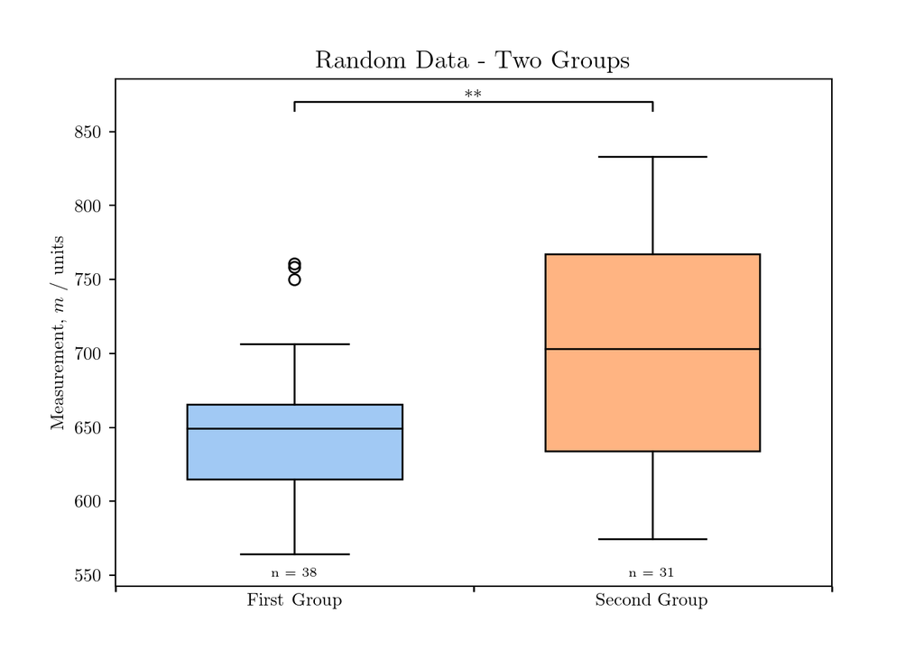

```python
data = []
for x in range(2):
    mu = 650 + 60 * x
    sigma = 50 + 20 * x
    n = 30 + np.random.randint(0, 60)
    data.append(np.random.normal(mu, sigma, n))
title = 'Random Data - Two Groups'
ylabel = r'Measurement, $m$ / units'
xticklabels = ['First Group', 'Second Group']
box_and_whisker(data, title, ylabel, xticklabels)
```

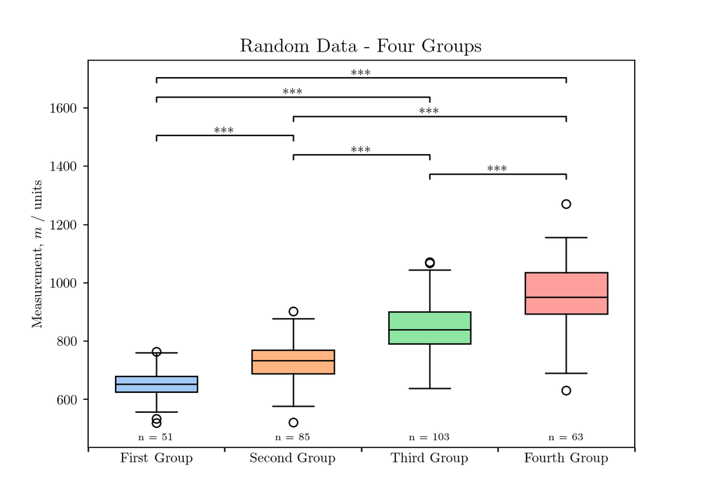

```python
data = []
for x in range(4):
    mu = 650 + 100 * x
    sigma = 50 + 20 * x
    n = 30 + np.random.randint(0, 100)
    data.append(np.random.normal(mu, sigma, n))
title = 'Random Data - Four Groups'
ylabel = r'Measurement, $m$ / units'
xticklabels = ['First Group', 'Second Group', 'Third Group', 'Fourth Group']
box_and_whisker(data, title, ylabel, xticklabels)
```

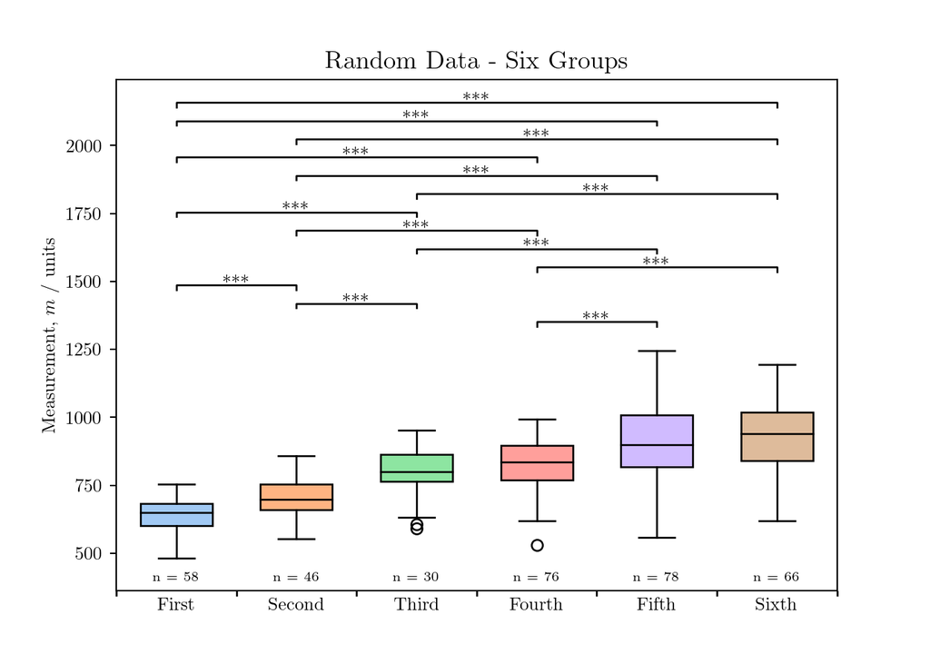

```python
data = []
for x in range(6):
    mu = 650 + 60 * x
    sigma = 50 + 20 * x
    n = 30 + np.random.randint(0, 60)
    data.append(np.random.normal(mu, sigma, n))
title = 'Random Data - Six Groups'
ylabel = r'Measurement, $m$ / units'
xticklabels = ['First', 'Second', 'Third', 'Fourth', 'Fifth', 'Sixth']
box_and_whisker(data, title, ylabel, xticklabels)
```

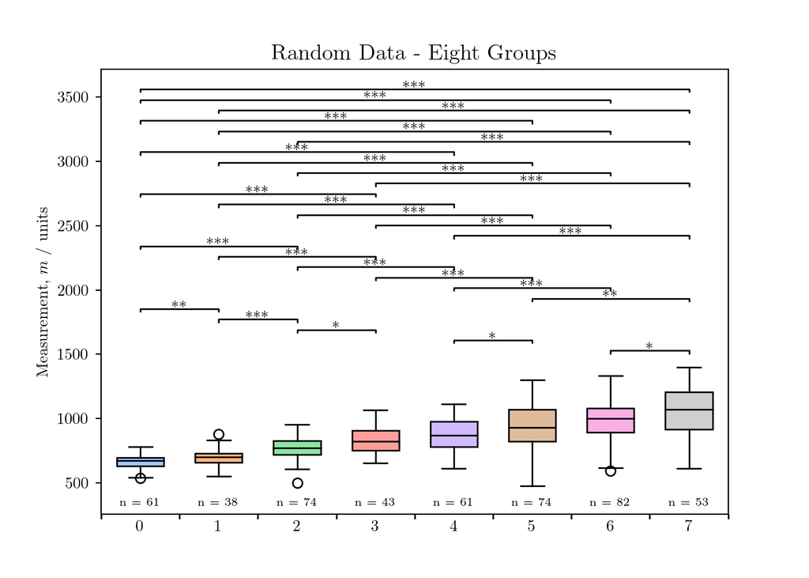

```python
data = []
for x in range(8):
    mu = 650 + 60 * x
    sigma = 50 + 20 * x
    n = 30 + np.random.randint(0, 60)
    data.append(np.random.normal(mu, sigma, n))
title = 'Random Data - Eight Groups'
ylabel = r'Measurement, $m$ / units'
xticklabels = ['0', '1', '2', '3', '4', '5', '6', '7']
box_and_whisker(data, title, ylabel, xticklabels)
```

⇦ Back